# RDA project

JBNU statistics

2021 12 14

## 목적 : 단동 비닐하우스 환기율 및 온습도에 대한 예측모형 구축 및 평가

## 사용모형 : Multiple Linear Regression Model v.s Artificial Neural Network Model (ANN)

## 1. Loading data (내부CO2 반응변수)

- 작물있음 데이터에서 외부CO2의 값이 결측치인 경우는 제외하였음.

```r
plantyes <- read.csv("C:/Users/HSY/Desktop/작물있음.csv",sep=",",header=T)
plantyes <- plantyes[is.na(plantyes$외부CO2)==FALSE,]
head(plantyes,10)
```

```
##    외부기온 내부기온 내외부기온차 외부상대습도 내부상대습도 내외부상대습도차
## 1      22.9     31.1          8.3         78.7         55.0             23.7
## 2      22.8     29.7          6.9         77.1         58.7             18.4
## 3      23.3     29.7          6.4         75.5         58.4             17.1
## 4      23.6     29.8          6.2         72.9         57.8             15.1
## 5      24.0     30.0          6.0         71.2         56.4             14.8
## 6      25.1     33.3          8.1         66.6         49.6             17.0
## 7      25.9     35.6          9.7         66.0         43.6             22.4
## 8      25.0     34.0          8.9         68.0         44.9             23.1
## 9      25.9     33.7          7.8         65.6         46.4             19.2
## 10     26.8     35.9          9.1         61.8         44.1             17.7
##    외부CO2 내부CO2 내외부CO2차 외부풍속 외부일사량 환기율 환기창면적 작물유무
## 1    469.5   462.0         7.5    1.398      372.7    5.4       0.15      yes
## 2    464.5   459.7         4.8    1.326      309.9    5.0       0.15      yes
## 3    457.5   451.3         6.2    0.835      291.9    4.0       0.15      yes
```

[output cut: 18 more lines]

```r
plantyes$작물유무 <- as.factor(plantyes$작물유무)
plantno <- read.csv("C:/Users/HSY/Desktop/작물없음.csv",sep=",",header=T)
head(plantno,10)
```

```
##    외부기온 내부기온 내외부기온차 외부상대습도 내부상대습도 내외부상대습도차
## 1      16.8     27.1         10.3         45.1         39.6              5.5
## 2      17.2     28.3         11.1         42.5         37.6              4.9
## 3      17.6     29.1         11.5         42.9         33.2              9.7
## 4      18.0     30.3         12.4         41.2         32.4              8.8
## 5      17.9     30.6         12.7         37.2         28.8              8.4
## 6      18.0     31.3         13.3         37.4         27.1             10.3
## 7      18.0     31.7         13.7         35.8         25.3             10.5
## 8      18.0     32.0         14.0         38.6         24.4             14.2
## 9      18.3     32.7         14.5         37.0         23.5             13.5
## 10     18.3     32.6         14.3         36.1         22.6             13.5
##    외부CO2 내부CO2 내외부CO2차 외부풍속 외부일사량 환기율 환기창면적 작물유무
## 1    543.5   608.0        64.5    1.576      409.4  0.704       0.04       no
## 2    543.0   580.0        37.0    1.707      442.7  0.756       0.04       no
## 3    522.5   585.5        63.0    1.342      476.5  0.634       0.04       no
```

[output cut: 18 more lines]

```r
plantno$작물유무 <- as.factor(plantno$작물유무)
plant <- rbind(plantno,plantyes)
```

## Multiple Linear Regression Model

## 2. 작물유무에 따라 데이터를 나누어서 분석 실시

### 2.1 작물이 없을 때

#### Multiple Linear Regression Model

- 먼저 변수들 간의 상관관계를 파악하기 위해 상관분석을 실시한다.

```r
ex1 <- plantno[,c(8,12,1,7,10,11,13,14,15)]
head(ex1)
```

```
##   내부CO2 환기율 외부기온 외부CO2 외부풍속 외부일사량 환기창면적 작물유무
## 1   608.0  0.704     16.8   543.5    1.576      409.4       0.04       no
## 2   580.0  0.756     17.2   543.0    1.707      442.7       0.04       no
## 3   585.5  0.634     17.6   522.5    1.342      476.5       0.04       no
## 4   593.5  0.798     18.0   543.0    1.802      505.7       0.04       no
## 5   590.5  1.084     17.9   520.5    2.583      536.0       0.04       no
## 6   585.5  1.493     18.0   529.5    3.660      564.9       0.04       no
##   작물유무수치
## 1            0
## 2            0
## 3            0
## 4            0
## 5            0
## 6            0
```

```r
ex2 <- ex1[,1:7]
```

```r
cor(ex2)
```

```
##                내부CO2     환기율      외부기온       외부CO2      외부풍속
## 내부CO2     1.00000000 -0.7537144 -3.248325e-02  9.330146e-02 -9.939070e-02
## 환기율     -0.75371440  1.0000000  1.668245e-01 -2.968640e-01  5.063954e-01
## 외부기온   -0.03248325  0.1668245  1.000000e+00 -3.112018e-01  3.063871e-01
## 외부CO2     0.09330146 -0.2968640 -3.112018e-01  1.000000e+00 -5.914228e-01
## 외부풍속   -0.09939070  0.5063954  3.063871e-01 -5.914228e-01  1.000000e+00
## 외부일사량 -0.03290872  0.0608040  3.274643e-01 -4.942462e-02  4.772916e-02
## 환기창면적 -0.86765569  0.8309530 -9.044468e-20  1.450984e-19  3.715441e-20
##               외부일사량    환기창면적
## 내부CO2    -3.290872e-02 -8.676557e-01
## 환기율      6.080400e-02  8.309530e-01
## 외부기온    3.274643e-01 -9.044468e-20
## 외부CO2    -4.942462e-02  1.450984e-19
## 외부풍속    4.772916e-02  3.715441e-20
## 외부일사량  1.000000e+00 -5.089237e-20
## 환기창면적 -5.089237e-20  1.000000e+00
```

- 산점도행렬과 상관계수그림을 그리면 다음과 같다.

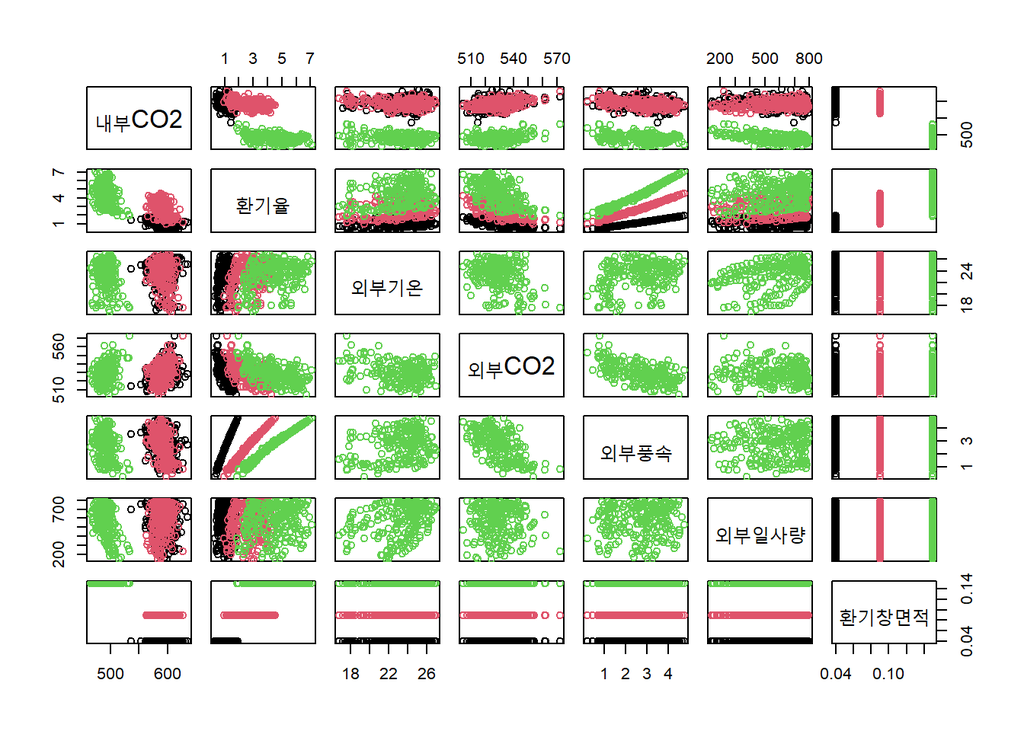

```r
pairs(ex2[1:nrow(plantno),],col=factor(ex2$환기창면적))
```

- 산점도를 통해 알 수 있는 사실은 환기율이 감소할수록 내부CO2가 증가한다는 점이다. 환기창면적과의 교호작용은 뚜렷하게 관측되는 것이 없으나, 외부풍속과의 교호작용의 존재 가능성이 추측된다. 외부풍속은 약하지만 내부CO2와 음의 상관을 보이는 것으로 생각된다.

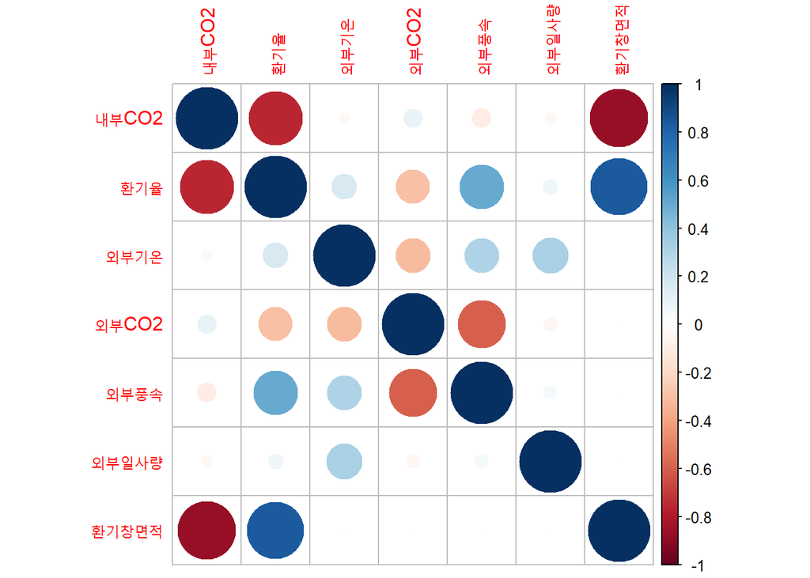

```r
library(corrplot)
corrplot(cor(ex2))
```

- 그리고 각 변수에 대한 기초통계량은 다음과 같이 계산된다.

```r
library(psych)
describe(ex1[,c(-8,-9)])
```

```
##            vars   n   mean     sd median trimmed    mad    min    max  range
## 내부CO2       1 735 558.49  49.02 582.50  561.63  29.65 464.50 635.50 171.00
## 환기율        2 735   2.81   1.64   2.64    2.68   1.86   0.32   7.09   6.78
## 외부기온      3 735  23.39   2.30  24.00   23.66   1.93  16.80  27.00  10.20
## 외부CO2       4 735 529.40  11.13 528.00  529.01  11.12 504.50 572.50  68.00
## 외부풍속      5 735   2.71   1.08   2.87    2.73   1.29   0.21   4.74   4.54
## 외부일사량    6 735 568.60 171.31 601.10  584.32 191.40 143.00 795.20 652.20
## 환기창면적    7 735   0.09   0.04   0.09    0.09   0.07   0.04   0.15   0.11
##             skew kurtosis   se
## 내부CO2    -0.60    -1.36 1.81
## 환기율      0.55    -0.67 0.06
## 외부기온   -0.98     0.30 0.08
## 외부CO2     0.47     0.44 0.41
## 외부풍속   -0.26    -0.99 0.04
## 외부일사량 -0.63    -0.61 6.32
## 환기창면적  0.11    -1.50 0.00
```

- 내부CO2를 반응변수로 하여 각 변수의 주효과와 환기창면적과의 교호작용을 고려한 다중선형회귀모형을 적합하면 다음과 같다.

```r
m_no <- lm(내부CO2~환기율+외부기온+외부CO2+외부풍속+외부일사량+환기창면적+환기창면적*환기율+환기창면적*외부기온+환기창면적*외부CO2+환기창면적*외부풍속+환기창면적*외부일사량,data=plantno)
summary(m_no)
```

```
##
## Call:
## lm(formula = 내부CO2 ~ 환기율 + 외부기온 + 외부CO2 + 외부풍속 +
##     외부일사량 + 환기창면적 + 환기창면적 * 환기율 + 환기창면적 *
##     외부기온 + 환기창면적 * 외부CO2 + 환기창면적 * 외부풍속 +
##     환기창면적 * 외부일사량, data = plantno)
##
## Residuals:
##     Min      1Q  Median      3Q     Max
## -48.512  -8.491   0.347   8.224  40.964
##
## Coefficients:
##                         Estimate Std. Error t value Pr(>|t|)
## (Intercept)            4.503e+02  7.022e+01   6.413 2.58e-10 ***
## 환기율                 5.204e+01  5.046e+00  10.313  < 2e-16 ***
## 외부기온               9.097e-01  5.382e-01   1.690   0.0914 .
## 외부CO2                3.174e-01  1.235e-01   2.570   0.0104 *
## 외부풍속              -3.058e+01  1.422e+00 -21.513  < 2e-16 ***
## 외부일사량            -7.023e-04  6.794e-03  -0.103   0.9177
## 환기창면적            -1.407e+02  6.780e+02  -0.208   0.8357
## 환기율:환기창면적     -4.288e+02  1.321e+01 -32.475  < 2e-16 ***
## 외부기온:환기창면적   -6.491e+00  5.194e+00  -1.250   0.2118
## 외부CO2:환기창면적    -7.995e-01  1.194e+00  -0.670   0.5033
## 외부풍속:환기창면적    2.629e+02  5.067e+01   5.187 2.78e-07 ***
## 외부일사량:환기창면적 -9.466e-02  7.132e-02  -1.327   0.1849
## ---
## Signif. codes:  0 '***' 0.001 '**' 0.01 '*' 0.05 '.' 0.1 ' ' 1
##
## Residual standard error: 12.84 on 723 degrees of freedom
## Multiple R-squared:  0.9324, Adjusted R-squared:  0.9314
## F-statistic: 906.6 on 11 and 723 DF,  p-value: < 2.2e-16
```

- 모형적합 결과 외부기온과 외부일사량, 그리고 환기창면적이 유의수준 0.05에서 유의미하지 않았다. 그러므로 외부기온과 외부일사량은 변수선택 시 제외해야 할 것으로 보이지만, 환기창면적의 경우는 일부 교호작용이 유의미한 경우가 존재하기 때문에 포함시키는 것이 좋을 것 같다고 판단된다.
- 그리고 교호작용들 중 환기율과 환기창면적, 그리고 외부풍속과 환기창면적 사이의 교호작용에 대한 t 통계량의 절대값이 첫번째와 두번째 순으로 가장 크므로 이를 가장 중요한 2가지 교호작용으로 결정한다.
- 조정된 결정계수의 값이 $R^2_{adj}=0.9314$이다.

#### Best subset selection

- 여러 측도들을 이용하여 모형에 포함될 변수를 적절히 선택해 보도록 하겠다.
- 분석 의뢰기관의 요청에 따라 환기율은 설명변수에서 제외하도록 한다.

```r
library(leaps)
ms0 <- regsubsets(내부CO2~외부기온+외부CO2+외부풍속+외부일사량+환기창면적+환기창면적*외부기온+환기창면적*외부CO2+환기창면적*외부풍속+환기창면적*외부일사량,data=plantno,nvmax=9)
ms0.summary <- summary(ms0)
ms0.summary
```

```
## Subset selection object
## Call: regsubsets.formula(내부CO2 ~ 외부기온 + 외부CO2 + 외부풍속 +
##     외부일사량 + 환기창면적 + 환기창면적 * 외부기온 + 환기창면적 *
##     외부CO2 + 환기창면적 * 외부풍속 + 환기창면적 * 외부일사량,
##     data = plantno, nvmax = 9)
## 9 Variables  (and intercept)
##                       Forced in Forced out
## 외부기온                  FALSE      FALSE
## 외부CO2                   FALSE      FALSE
## 외부풍속                  FALSE      FALSE
## 외부일사량                FALSE      FALSE
## 환기창면적                FALSE      FALSE
## 외부기온:환기창면적       FALSE      FALSE
## 외부CO2:환기창면적        FALSE      FALSE
## 외부풍속:환기창면적       FALSE      FALSE
## 외부일사량:환기창면적     FALSE      FALSE
## 1 subsets of each size up to 9
## Selection Algorithm: exhaustive
##          외부기온 외부CO2 외부풍속 외부일사량 환기창면적 외부기온:환기창면적
## 1  ( 1 ) " "      " "     " "      " "        "*"        " "
## 2  ( 1 ) " "      " "     "*"      " "        "*"        " "
## 3  ( 1 ) " "      "*"     "*"      " "        " "        " "
## 4  ( 1 ) " "      "*"     "*"      " "        " "        " "
## 5  ( 1 ) " "      "*"     "*"      "*"        " "        " "
## 6  ( 1 ) "*"      "*"     "*"      "*"        " "        " "
## 7  ( 1 ) "*"      "*"     "*"      "*"        " "        "*"
## 8  ( 1 ) "*"      "*"     "*"      "*"        " "        "*"
## 9  ( 1 ) "*"      "*"     "*"      "*"        "*"        "*"
##          외부CO2:환기창면적 외부풍속:환기창면적 외부일사량:환기창면적
## 1  ( 1 ) " "                " "                 " "
## 2  ( 1 ) " "                " "                 " "
## 3  ( 1 ) "*"                " "                 " "
## 4  ( 1 ) "*"                " "                 "*"
## 5  ( 1 ) "*"                " "                 "*"
## 6  ( 1 ) "*"                " "                 "*"
## 7  ( 1 ) "*"                " "                 "*"
## 8  ( 1 ) "*"                "*"                 "*"
## 9  ( 1 ) "*"                "*"                 "*"
```

```r
par(mfrow=c(2,2))
# RSS=SSE
plot(ms0.summary$rss,xlab="Number of Variables",ylab="RSS",type="l")
# Adj R^2
plot(ms0.summary$adjr2,xlab="Number of Variables",ylab="Adjusted RSq",type="l")
which.max(ms0.summary$adjr2)
```

```
## [1] 5
```

```r
points(which.max(ms0.summary$adjr2)
,ms0.summary$adjr2[which.max(ms0.summary$adjr2)
], col="red",cex=2,pch=20)
# Cp
plot(ms0.summary$cp,xlab="Number of Variables",ylab="Cp",type='l')
which.min(ms0.summary$cp)
```

```
## [1] 4
```

```r
points(which.min(ms0.summary$cp)
,ms0.summary$cp[which.min(ms0.summary$cp)
],col="red",cex=2,pch=20)
# BIC
plot(ms0.summary$bic,xlab="Number of Variables",ylab="BIC",type='l')
which.min(ms0.summary$bic)
```

```
## [1] 2
```

```r
points(which.min(ms0.summary$bic)
,ms0.summary$bic[which.min(ms0.summary$bic)
],col="red",cex=2,pch=20)
```

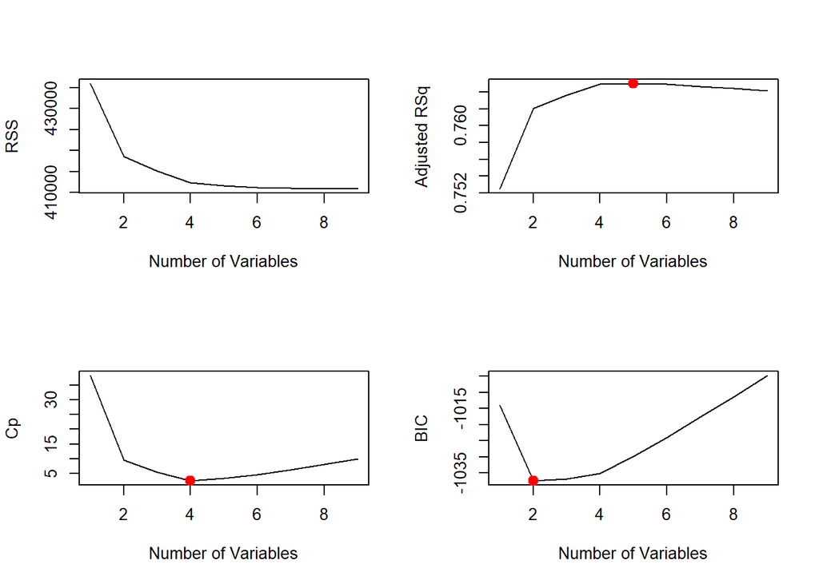

```r
par(mfrow=c(1,1))
```

- 외부기온을 제외하는 것이 좋다는 결과이다.
- 외부기온을 제외한 모형에 대해서 다시한번 선택해 보자.

```r
library(leaps)
ms0 <- regsubsets(내부CO2~외부CO2+외부풍속+외부일사량+환기창면적+환기창면적*외부CO2+환기창면적*외부풍속+환기창면적*외부일사량,data=plantno,nvmax=7)
ms0.summary <- summary(ms0)
ms0.summary
```

```
## Subset selection object
## Call: regsubsets.formula(내부CO2 ~ 외부CO2 + 외부풍속 + 외부일사량 +
##     환기창면적 + 환기창면적 * 외부CO2 + 환기창면적 * 외부풍속 +
##     환기창면적 * 외부일사량, data = plantno, nvmax = 7)
## 7 Variables  (and intercept)
##                       Forced in Forced out
## 외부CO2                   FALSE      FALSE
## 외부풍속                  FALSE      FALSE
## 외부일사량                FALSE      FALSE
## 환기창면적                FALSE      FALSE
## 외부CO2:환기창면적        FALSE      FALSE
## 외부풍속:환기창면적       FALSE      FALSE
## 외부일사량:환기창면적     FALSE      FALSE
## 1 subsets of each size up to 7
## Selection Algorithm: exhaustive
##          외부CO2 외부풍속 외부일사량 환기창면적 외부CO2:환기창면적
## 1  ( 1 ) " "     " "      " "        "*"        " "
## 2  ( 1 ) " "     "*"      " "        "*"        " "
## 3  ( 1 ) "*"     "*"      " "        " "        "*"
## 4  ( 1 ) "*"     "*"      " "        " "        "*"
## 5  ( 1 ) "*"     "*"      "*"        " "        "*"
## 6  ( 1 ) "*"     "*"      "*"        " "        "*"
## 7  ( 1 ) "*"     "*"      "*"        "*"        "*"
##          외부풍속:환기창면적 외부일사량:환기창면적
## 1  ( 1 ) " "                 " "
## 2  ( 1 ) " "                 " "
## 3  ( 1 ) " "                 " "
## 4  ( 1 ) " "                 "*"
## 5  ( 1 ) " "                 "*"
## 6  ( 1 ) "*"                 "*"
## 7  ( 1 ) "*"                 "*"
```

```r
par(mfrow=c(2,2))
# RSS=SSE
plot(ms0.summary$rss,xlab="Number of Variables",ylab="RSS",type="l")
# Adj R^2
plot(ms0.summary$adjr2,xlab="Number of Variables",ylab="Adjusted RSq",type="l")
which.max(ms0.summary$adjr2)
```

```
## [1] 5
```

```r
points(which.max(ms0.summary$adjr2)
,ms0.summary$adjr2[which.max(ms0.summary$adjr2)
], col="red",cex=2,pch=20)
# Cp
plot(ms0.summary$cp,xlab="Number of Variables",ylab="Cp",type='l')
which.min(ms0.summary$cp)
```

```
## [1] 4
```

```r
points(which.min(ms0.summary$cp)
,ms0.summary$cp[which.min(ms0.summary$cp)
],col="red",cex=2,pch=20)
# BIC
plot(ms0.summary$bic,xlab="Number of Variables",ylab="BIC",type='l')
which.min(ms0.summary$bic)
```

```
## [1] 2
```

```r
points(which.min(ms0.summary$bic)
,ms0.summary$bic[which.min(ms0.summary$bic)
],col="red",cex=2,pch=20)
```

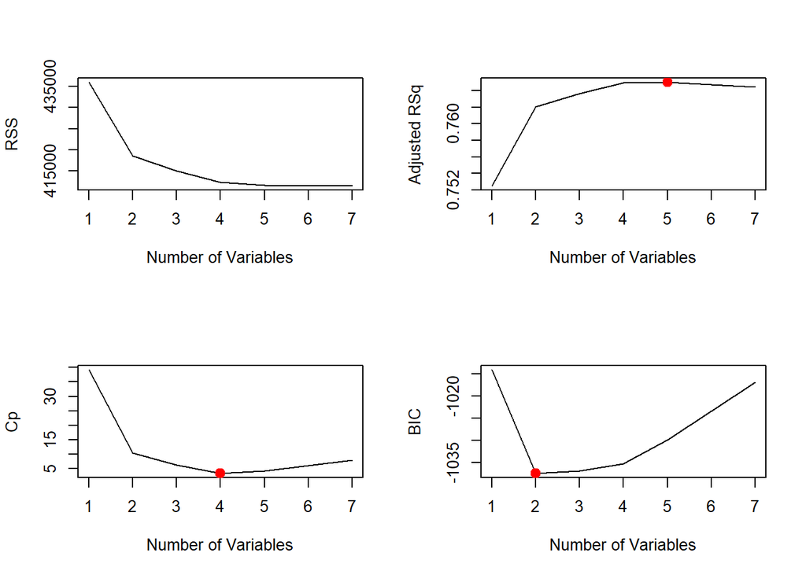

```r
par(mfrow=c(1,1))
```

- 분석결과 $R_{adj}^2$의 경우는 변수의 개수 5인 모형, $Cp$의 경우는 변수의 개수 4인 모형, 그리고 $BIC$의 경우는 변수의 개수 2인 모형을 최적으로 판단하고 있다. 이들 중 가장 단순한 모형인 변수의 개수 2인 모형을 최종적으로 선택하도록 한다. 복잡한 모형이 항상 바람직한 결과를 주지는 않으며 단순한 모형도 설명력이 높은 경우가 많기 때문이다.

#### 교차타당검증에 의한 모형 비교

```r
set.seed(5790)
train.index <- sample(1:nrow(plantno), round(nrow(plantno)*7/10), replace=F)
ex1_train <- plantno[train.index,]
ex1_test <- plantno[-train.index,]
```

```r
# 모든 주효과, 그리고 환기창면적과 다른 변수들 사이의 교호작용을 포함한 모형
m0 <- lm(내부CO2~환기율+외부기온+외부CO2+외부풍속+외부일사량+환기창면적+환기창면적*환기율+환기창면적*외부기온+환기창면적*외부CO2+환기창면적*외부풍속+환기창면적*외부일사량,data=ex1_train)
y_hat0 <- predict(m0,ex1_test)
RMSE0 <- mean(sum((ex1_test$내부CO2-y_hat0)^2))
RMSE0
```

```
## [1] 35268.63
```

```r
# Adj R^2, Cp, BIC 등의 기준을 바탕으로 선택된 모형 (교호작용이 있는 경우는 주효과 포함)
m0 <- lm(내부CO2~외부풍속+환기창면적,data=ex1_train)
y_hat0 <- predict(m0,ex1_test)
RMSE1 <- mean(sum((ex1_test$내부CO2-y_hat0)^2))
RMSE1
```

```
## [1] 122424.2
```

```r
# 모든 주효과와 가장 중요한 교호작용 1가지를 포함한 모형 (분석 의뢰기관의 요청에 따라 환기율은 제외)
m0 <- lm(내부CO2~외부기온+외부CO2+외부풍속+외부일사량+환기창면적+환기창면적*외부풍속,data=ex1_train)
y_hat0 <- predict(m0,ex1_test)
RMSE2 <- mean(sum((ex1_test$내부CO2-y_hat0)^2))
RMSE2
```

```
## [1] 120660.3
```

- 결과적으로 3가지 모형들 중 모든 주효과, 그리고 환기창면적과 다른 변수들 사이의 교호작용을 포함한 모형이 가장 우수하였다.

```r
summary(lm(내부CO2~환기율+외부기온+외부CO2+외부풍속+외부일사량+환기창면적+환기창면적*환기율+환기창면적*외부기온+환기창면적*외부CO2+환기창면적*외부풍속+환기창면적*외부일사량,data=ex1_train))
```

```
##
## Call:
## lm(formula = 내부CO2 ~ 환기율 + 외부기온 + 외부CO2 + 외부풍속 +
##     외부일사량 + 환기창면적 + 환기창면적 * 환기율 + 환기창면적 *
##     외부기온 + 환기창면적 * 외부CO2 + 환기창면적 * 외부풍속 +
##     환기창면적 * 외부일사량, data = ex1_train)
##
## Residuals:
##     Min      1Q  Median      3Q     Max
## -39.723  -8.843   0.495   9.193  40.395
##
## Coefficients:
##                         Estimate Std. Error t value Pr(>|t|)
## (Intercept)            5.520e+02  8.649e+01   6.382 3.97e-10 ***
## 환기율                 5.490e+01  6.113e+00   8.982  < 2e-16 ***
## 외부기온               5.616e-01  6.865e-01   0.818 0.413728
## 외부CO2                1.424e-01  1.500e-01   0.949 0.342930
## 외부풍속              -3.046e+01  1.684e+00 -18.086  < 2e-16 ***
## 외부일사량             1.945e-03  8.545e-03   0.228 0.820005
## 환기창면적            -1.016e+03  8.486e+02  -1.198 0.231555
## 환기율:환기창면적     -4.213e+02  1.599e+01 -26.349  < 2e-16 ***
## 외부기온:환기창면적   -5.022e+00  6.685e+00  -0.751 0.452838
## 외부CO2:환기창면적     6.983e-01  1.476e+00   0.473 0.636289
## 외부풍속:환기창면적    2.346e+02  6.209e+01   3.778 0.000177 ***
## 외부일사량:환기창면적 -1.208e-01  8.912e-02  -1.355 0.176047
## ---
## Signif. codes:  0 '***' 0.001 '**' 0.01 '*' 0.05 '.' 0.1 ' ' 1
##
## Residual standard error: 13 on 502 degrees of freedom
## Multiple R-squared:  0.9316, Adjusted R-squared:  0.9301
## F-statistic: 621.9 on 11 and 502 DF,  p-value: < 2.2e-16
```

### 2.2 작물이 있을 때

#### Multiple Linear Regression Model

- 먼저 변수들 간의 상관관계를 파악하기 위해 상관분석을 실시한다.

```r
ex1 <- plantyes[,c(8,12,1,7,10,11,13,14,15)]
head(ex1)
```

```
##   내부CO2 환기율 외부기온 외부CO2 외부풍속 외부일사량 환기창면적 작물유무
## 1   462.0    5.4     22.9   469.5    1.398      372.7       0.15      yes
## 2   459.7    5.0     22.8   464.5    1.326      309.9       0.15      yes
## 3   451.3    4.0     23.3   457.5    0.835      291.9       0.15      yes
## 4   445.7    4.2     23.6   453.0    0.943      297.5       0.15      yes
## 5   441.7    5.2     24.0   447.5    1.481      335.4       0.15      yes
## 6   440.0    4.9     25.1   447.0    1.132      549.7       0.15      yes
##   작물유무수치
## 1            1
## 2            1
## 3            1
## 4            1
## 5            1
## 6            1
```

```r
ex2 <- ex1[,1:7]
```

```r
cor(ex2)
```

```
##                 내부CO2      환기율    외부기온     외부CO2    외부풍속
## 내부CO2     1.000000000 -0.27855946 -0.24025438  0.47487406 -0.21125322
## 환기율     -0.278559460  1.00000000  0.04996941  0.08670164  0.76546935
## 외부기온   -0.240254376  0.04996941  1.00000000 -0.34584154  0.12445561
## 외부CO2     0.474874058  0.08670164 -0.34584154  1.00000000 -0.03373841
## 외부풍속   -0.211253224  0.76546935  0.12445561 -0.03373841  1.00000000
## 외부일사량  0.005474763  0.10313855  0.47323743  0.00495494  0.01247939
## 환기창면적 -0.243066151  0.67141924 -0.08617862  0.09690856  0.10718424
##              외부일사량  환기창면적
## 내부CO2     0.005474763 -0.24306615
## 환기율      0.103138552  0.67141924
## 외부기온    0.473237433 -0.08617862
## 외부CO2     0.004954940  0.09690856
## 외부풍속    0.012479390  0.10718424
## 외부일사량  1.000000000 -0.01979362
## 환기창면적 -0.019793616  1.00000000
```

- 산점도행렬과 상관계수그림을 그리면 다음과 같다.

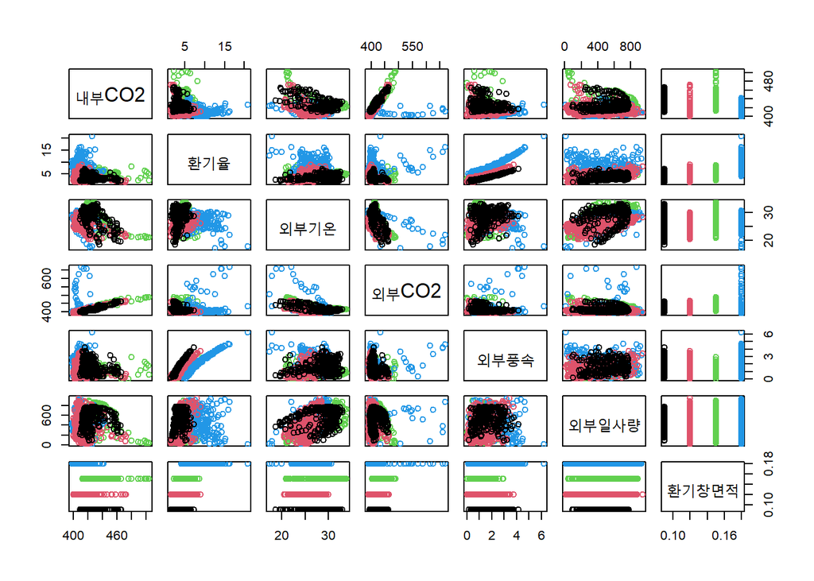

```r
pairs(ex2[1:nrow(plantyes),],col=factor(ex2$환기창면적))
```

- 산점도를 통해 알 수 있는 사실은 환기율과 외부풍속이 감소할수록 내부CO2가 증가한다는 점이다. 환기창면적과의 교호작용은 뚜렷하게 관측되는 것이 없으나, 외부풍속과의 교호작용의 존재 가능성이 추측된다. 외부풍속은 약하지만 내부CO2와 음의 상관을 보이는 것으로 생각된다.

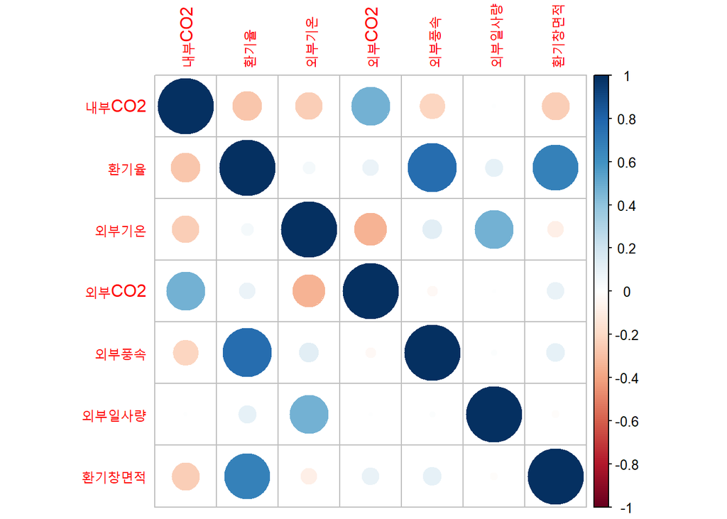

```r
library(corrplot)
corrplot(cor(ex2))
```

- 그리고 각 변수에 대한 기초통계량은 다음과 같이 계산된다.

```r
library(psych)
describe(ex1[,c(-8,-9)])
```

```
##            vars    n   mean     sd median trimmed    mad    min    max  range
## 내부CO2       1 1055 419.45  14.70 416.30  417.26  11.27 398.30 504.00 105.70
## 환기율        2 1055   5.15   2.58   4.60    4.77   2.08   1.40  20.90  19.50
## 외부기온      3 1055  26.91   2.99  26.90   26.94   3.26  17.30  33.90  16.60
## 외부CO2       4 1055 414.52  25.67 409.00  410.10  11.12 389.50 669.50 280.00
## 외부풍속      5 1055   1.50   0.92   1.30    1.41   0.83   0.00   6.22   6.21
## 외부일사량    6 1055 459.27 225.19 459.20  460.76 275.02  10.04 950.00 939.96
## 환기창면적    7 1055   0.13   0.03   0.12    0.13   0.04   0.09   0.18   0.09
##             skew kurtosis   se
## 내부CO2     1.99     6.07 0.45
## 환기율      1.62     3.44 0.08
## 외부기온   -0.12    -0.42 0.09
## 외부CO2     5.09    37.41 0.79
## 외부풍속    0.97     0.80 0.03
## 외부일사량 -0.02    -1.02 6.93
## 환기창면적  0.12    -1.38 0.00
```

- 내부CO2를 반응변수로 하여 각 변수의 주효과와 환기창면적과의 교호작용을 고려한 다중선형회귀모형을 적합하면 다음과 같다.

```r
m_yes <- lm(내부CO2~환기율+외부기온+외부CO2+외부풍속+외부일사량+환기창면적+환기창면적*환기율+환기창면적*외부기온+환기창면적*외부CO2+환기창면적*외부풍속+환기창면적*외부일사량,data=plantyes)
summary(m_yes)
```

```
##
## Call:
## lm(formula = 내부CO2 ~ 환기율 + 외부기온 + 외부CO2 + 외부풍속 +
##     외부일사량 + 환기창면적 + 환기창면적 * 환기율 + 환기창면적 *
##     외부기온 + 환기창면적 * 외부CO2 + 환기창면적 * 외부풍속 +
##     환기창면적 * 외부일사량, data = plantyes)
##
## Residuals:
##     Min      1Q  Median      3Q     Max
## -23.367  -4.244  -0.991   3.202  41.084
##
## Coefficients:
##                         Estimate Std. Error t value Pr(>|t|)
## (Intercept)           -9.581e+02  3.154e+01 -30.374  < 2e-16 ***
## 환기율                 1.242e+01  1.328e+00   9.353  < 2e-16 ***
## 외부기온               7.390e+00  4.057e-01  18.214  < 2e-16 ***
## 외부CO2                2.794e+00  5.847e-02  47.783  < 2e-16 ***
## 외부풍속              -1.612e+01  1.985e+00  -8.121  1.3e-15 ***
## 외부일사량            -8.455e-03  4.827e-03  -1.751   0.0802 .
## 환기창면적             8.016e+03  2.021e+02  39.673  < 2e-16 ***
## 환기율:환기창면적     -9.282e+01  7.134e+00 -13.011  < 2e-16 ***
## 외부기온:환기창면적   -5.465e+01  3.055e+00 -17.890  < 2e-16 ***
## 외부CO2:환기창면적    -1.539e+01  3.526e-01 -43.645  < 2e-16 ***
## 외부풍속:환기창면적    1.340e+02  1.598e+01   8.386  < 2e-16 ***
## 외부일사량:환기창면적  8.875e-02  3.499e-02   2.536   0.0113 *
## ---
## Signif. codes:  0 '***' 0.001 '**' 0.01 '*' 0.05 '.' 0.1 ' ' 1
##
## Residual standard error: 7.006 on 1043 degrees of freedom
## Multiple R-squared:  0.7753, Adjusted R-squared:  0.773
## F-statistic: 327.2 on 11 and 1043 DF,  p-value: < 2.2e-16
```

#### Best subset selection

- 여러 측도들을 이용하여 모형에 포함될 변수를 적절히 선택해 보도록 하겠다.
- 분석 의뢰기관의 요청에 따라 환기율은 제외하고 분석한다.

```r
library(leaps)
ms0 <- regsubsets(내부CO2~외부기온+외부CO2+외부풍속+외부일사량+환기창면적+환기창면적*외부기온+환기창면적*외부CO2+환기창면적*외부풍속+환기창면적*외부일사량,data=plantyes,nvmax=9)
ms0.summary <- summary(ms0)
ms0.summary
```

```
## Subset selection object
## Call: regsubsets.formula(내부CO2 ~ 외부기온 + 외부CO2 + 외부풍속 +
##     외부일사량 + 환기창면적 + 환기창면적 * 외부기온 + 환기창면적 *
##     외부CO2 + 환기창면적 * 외부풍속 + 환기창면적 * 외부일사량,
##     data = plantyes, nvmax = 9)
## 9 Variables  (and intercept)
##                       Forced in Forced out
## 외부기온                  FALSE      FALSE
## 외부CO2                   FALSE      FALSE
## 외부풍속                  FALSE      FALSE
## 외부일사량                FALSE      FALSE
## 환기창면적                FALSE      FALSE
## 외부기온:환기창면적       FALSE      FALSE
## 외부CO2:환기창면적        FALSE      FALSE
## 외부풍속:환기창면적       FALSE      FALSE
## 외부일사량:환기창면적     FALSE      FALSE
## 1 subsets of each size up to 9
## Selection Algorithm: exhaustive
##          외부기온 외부CO2 외부풍속 외부일사량 환기창면적 외부기온:환기창면적
## 1  ( 1 ) " "      "*"     " "      " "        " "        " "
## 2  ( 1 ) " "      "*"     " "      " "        " "        " "
## 3  ( 1 ) " "      "*"     " "      " "        "*"        " "
## 4  ( 1 ) " "      "*"     " "      " "        "*"        " "
## 5  ( 1 ) "*"      "*"     " "      " "        "*"        "*"
## 6  ( 1 ) "*"      "*"     " "      " "        "*"        "*"
## 7  ( 1 ) "*"      "*"     "*"      " "        "*"        "*"
## 8  ( 1 ) "*"      "*"     "*"      "*"        "*"        "*"
## 9  ( 1 ) "*"      "*"     "*"      "*"        "*"        "*"
##          외부CO2:환기창면적 외부풍속:환기창면적 외부일사량:환기창면적
## 1  ( 1 ) " "                " "                 " "
## 2  ( 1 ) "*"                " "                 " "
## 3  ( 1 ) "*"                " "                 " "
## 4  ( 1 ) "*"                "*"                 " "
## 5  ( 1 ) "*"                " "                 " "
## 6  ( 1 ) "*"                "*"                 " "
## 7  ( 1 ) "*"                "*"                 " "
## 8  ( 1 ) "*"                "*"                 " "
## 9  ( 1 ) "*"                "*"                 "*"
```

```r
par(mfrow=c(2,2))
# RSS=SSE
plot(ms0.summary$rss,xlab="Number of Variables",ylab="RSS",type="l")
# Adj R^2
plot(ms0.summary$adjr2,xlab="Number of Variables",ylab="Adjusted RSq",type="l")
which.max(ms0.summary$adjr2)
```

```
## [1] 7
```

```r
points(which.max(ms0.summary$adjr2)
,ms0.summary$adjr2[which.max(ms0.summary$adjr2)
], col="red",cex=2,pch=20)
# Cp
plot(ms0.summary$cp,xlab="Number of Variables",ylab="Cp",type='l')
which.min(ms0.summary$cp)
```

```
## [1] 7
```

```r
points(which.min(ms0.summary$cp)
,ms0.summary$cp[which.min(ms0.summary$cp)
],col="red",cex=2,pch=20)
# BIC
plot(ms0.summary$bic,xlab="Number of Variables",ylab="BIC",type='l')
which.min(ms0.summary$bic)
```

```
## [1] 7
```

```r
points(which.min(ms0.summary$bic)
,ms0.summary$bic[which.min(ms0.summary$bic)
],col="red",cex=2,pch=20)
```

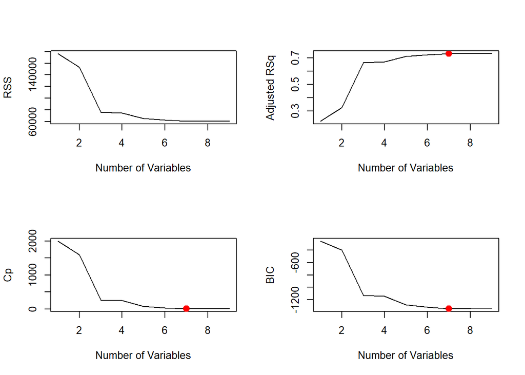

```r
par(mfrow=c(1,1))
```

```r
library(leaps)
ms0 <- regsubsets(내부CO2~외부기온+외부CO2+환기창면적+환기창면적*외부기온+환기창면적*외부CO2,data=plantyes,nvmax=5)
ms0.summary <- summary(ms0)
ms0.summary
```

```
## Subset selection object
## Call: regsubsets.formula(내부CO2 ~ 외부기온 + 외부CO2 + 환기창면적 +
##     환기창면적 * 외부기온 + 환기창면적 * 외부CO2, data = plantyes,
##     nvmax = 5)
## 5 Variables  (and intercept)
##                     Forced in Forced out
## 외부기온                FALSE      FALSE
## 외부CO2                 FALSE      FALSE
## 환기창면적              FALSE      FALSE
## 외부기온:환기창면적     FALSE      FALSE
## 외부CO2:환기창면적      FALSE      FALSE
## 1 subsets of each size up to 5
## Selection Algorithm: exhaustive
##          외부기온 외부CO2 환기창면적 외부기온:환기창면적 외부CO2:환기창면적
## 1  ( 1 ) " "      "*"     " "        " "                 " "
## 2  ( 1 ) " "      "*"     " "        " "                 "*"
## 3  ( 1 ) " "      "*"     "*"        " "                 "*"
## 4  ( 1 ) "*"      "*"     "*"        " "                 "*"
## 5  ( 1 ) "*"      "*"     "*"        "*"                 "*"
```

```r
par(mfrow=c(2,2))
# RSS=SSE
plot(ms0.summary$rss,xlab="Number of Variables",ylab="RSS",type="l")
# Adj R^2
plot(ms0.summary$adjr2,xlab="Number of Variables",ylab="Adjusted RSq",type="l")
which.max(ms0.summary$adjr2)
```

```
## [1] 5
```

```r
points(which.max(ms0.summary$adjr2)
,ms0.summary$adjr2[which.max(ms0.summary$adjr2)
], col="red",cex=2,pch=20)
# Cp
plot(ms0.summary$cp,xlab="Number of Variables",ylab="Cp",type='l')
which.min(ms0.summary$cp)
```

```
## [1] 5
```

```r
points(which.min(ms0.summary$cp)
,ms0.summary$cp[which.min(ms0.summary$cp)
],col="red",cex=2,pch=20)
# BIC
plot(ms0.summary$bic,xlab="Number of Variables",ylab="BIC",type='l')
which.min(ms0.summary$bic)
```

```
## [1] 5
```

```r
points(which.min(ms0.summary$bic)
,ms0.summary$bic[which.min(ms0.summary$bic)
],col="red",cex=2,pch=20)
```

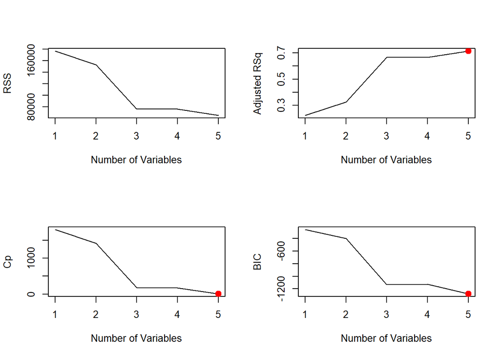

```r
par(mfrow=c(1,1))
```

- 분석결과 $R_{adj}^2$의 경우는 변수의 개수 5인 모형, $Cp$의 경우는 변수의 개수 5인 모형, 그리고 $BIC$의 경우는 변수의 개수 5인 모형을 최적으로 판단하고 있다. 이들 중 가장 단순한 모형인 변수의 개수 5인 모형을 최종적으로 선택하도록 한다.

#### 교차타당검증에 의한 모형 비교

```r
set.seed(5790)
train.index <- sample(1:nrow(plantyes), round(nrow(plantyes)*7/10), replace=F)
ex1_train <- plantyes[train.index,]
ex1_test <- plantyes[-train.index,]
```

```r
# 모든 주효과, 그리고 환기창면적과 다른 변수들 사이의 교호작용을 포함한 모형
m0 <- lm(내부CO2~환기율+외부기온+외부CO2+외부풍속+외부일사량+환기창면적+환기창면적*환기율+환기창면적*외부기온+환기창면적*외부CO2+환기창면적*외부풍속+환기창면적*외부일사량,data=ex1_train)
y_hat0 <- predict(m0,ex1_test)
RMSE0 <- mean(sum((ex1_test$내부CO2-y_hat0)^2))
RMSE0
```

```
## [1] 14174.77
```

```r
# Adj R^2, Cp, BIC 등의 기준을 통해 선택된 모형
m0 <- lm(내부CO2~외부기온+외부CO2+환기창면적+환기창면적*외부기온+환기창면적*외부CO2,data=ex1_train)
y_hat0 <- predict(m0,ex1_test)
RMSE1 <- mean(sum((ex1_test$내부CO2-y_hat0)^2))
RMSE1
```

```
## [1] 18546.99
```

```r
# 모든 주효과와 가장 중요한 교호작용 1가지를 포함한 모형 (분석 의뢰기관의 요청에 따라 환기율은 제외)
m0 <- lm(내부CO2~외부기온+외부CO2+외부풍속+외부일사량+환기창면적+환기창면적*외부CO2,data=ex1_train)
y_hat0 <- predict(m0,ex1_test)
RMSE2 <- mean(sum((ex1_test$내부CO2-y_hat0)^2))
RMSE2
```

```
## [1] 21280.65
```

- 결과적으로 모든 주효과, 그리고 환기창면적과 다른 변수들 사이의 교호작용을 포함한 모형이 가장 우수하였다.

```r
summary(lm(내부CO2~환기율+외부기온+외부CO2+외부풍속+외부일사량+환기창면적+환기창면적*환기율+환기창면적*외부기온+환기창면적*외부CO2+환기창면적*외부풍속+환기창면적*외부일사량,data=ex1_train))
```

```
##
## Call:
## lm(formula = 내부CO2 ~ 환기율 + 외부기온 + 외부CO2 + 외부풍속 +
##     외부일사량 + 환기창면적 + 환기창면적 * 환기율 + 환기창면적 *
##     외부기온 + 환기창면적 * 외부CO2 + 환기창면적 * 외부풍속 +
##     환기창면적 * 외부일사량, data = ex1_train)
##
## Residuals:
##     Min      1Q  Median      3Q     Max
## -24.020  -4.237  -1.183   3.263  38.922
##
## Coefficients:
##                         Estimate Std. Error t value Pr(>|t|)
## (Intercept)           -9.836e+02  3.901e+01 -25.215  < 2e-16 ***
## 환기율                 1.016e+01  1.673e+00   6.074 2.01e-09 ***
## 외부기온               7.599e+00  5.070e-01  14.988  < 2e-16 ***
## 외부CO2                2.848e+00  7.214e-02  39.474  < 2e-16 ***
## 외부풍속              -1.423e+01  2.461e+00  -5.782 1.10e-08 ***
## 외부일사량            -9.608e-03  6.050e-03  -1.588   0.1127
## 환기창면적             8.180e+03  2.481e+02  32.977  < 2e-16 ***
## 환기율:환기창면적     -8.438e+01  8.875e+00  -9.507  < 2e-16 ***
## 외부기온:환기창면적   -5.612e+01  3.803e+00 -14.756  < 2e-16 ***
## 외부CO2:환기창면적    -1.569e+01  4.327e-01 -36.260  < 2e-16 ***
## 외부풍속:환기창면적    1.327e+02  1.937e+01   6.850 1.58e-11 ***
## 외부일사량:환기창면적  1.018e-01  4.336e-02   2.348   0.0192 *
## ---
## Signif. codes:  0 '***' 0.001 '**' 0.01 '*' 0.05 '.' 0.1 ' ' 1
##
## Residual standard error: 7.171 on 726 degrees of freedom
## Multiple R-squared:  0.7755, Adjusted R-squared:  0.7721
## F-statistic:   228 on 11 and 726 DF,  p-value: < 2.2e-16
```

### 2.3 작물유무 데이터를 합친 경우

#### Multiple Linear Regression Model

- 상관관계에 대한 분석은 작물유무에 따라 데이터를 나누어 분석하는 과정에서 모두 다루었기 때문에 생략하도록 한다.
- 2.1절과 2.2절의 결과를 통해 환기창면적과 환기율, 환기창면적과 외부풍속, 그리고 환기창면적과 외부CO2 사이의 교호작용이 유의미하다는 사실을 파악할 수 있다.
- 여기에서는 작물유무에 대한 변수가 추가로 들어가고 이에 따라 작물유무에 대한 교호작용을 포함해서 다양한 교호작용 변수를 고려할 수 있지만 모형이 너무 복잡해지므로 바람직하지 않다. 오히려 중요한 교호작용만을 포함한 모형도 충분한 설명력을 가지기 때문이다.
- 따라서 내부CO2를 반응변수로 하여 각 변수의 주효과와 환기창면적과 환기율, 환기창면적과 외부풍속, 그리고 환기창면적과 외부CO2 사이의 교호작용을 포함한 모형을 시작점으로 하여 분석을 진행하도록 한다. 여기에 주효과와 작물유무 사이의 교호작용도 우선 포함한다.

```r
m_total <- lm(내부CO2~환기율+외부기온+외부CO2+외부풍속+외부일사량+환기창면적+작물유무+환기창면적*환기율+환기창면적*외부풍속+환기창면적*외부CO2+작물유무*환기율+작물유무*외부기온+작물유무*외부CO2+작물유무*외부풍속+작물유무*외부일사량+작물유무*환기창면적,data=plant)
summary(m_total)
```

```
##
## Call:
## lm(formula = 내부CO2 ~ 환기율 + 외부기온 + 외부CO2 + 외부풍속 +
##     외부일사량 + 환기창면적 + 작물유무 + 환기창면적 * 환기율 +
##     환기창면적 * 외부풍속 + 환기창면적 * 외부CO2 + 작물유무 *
##     환기율 + 작물유무 * 외부기온 + 작물유무 * 외부CO2 + 작물유무 *
##     외부풍속 + 작물유무 * 외부일사량 + 작물유무 * 환기창면적,
##     data = plant)
##
## Residuals:
##     Min      1Q  Median      3Q     Max
## -48.540  -8.780   0.226   8.784  56.976
##
## Coefficients:
##                          Estimate Std. Error t value Pr(>|t|)
## (Intercept)            -5.627e+01  4.210e+01  -1.336  0.18161
## 환기율                  2.257e+01  2.637e+00   8.557  < 2e-16 ***
## 외부기온                3.330e-01  2.433e-01   1.369  0.17131
## 외부CO2                 1.300e+00  7.483e-02  17.378  < 2e-16 ***
## 외부풍속               -1.624e+01  1.263e+00 -12.863  < 2e-16 ***
## 외부일사량             -6.388e-03  3.236e-03  -1.974  0.04852 *
## 환기창면적              5.283e+03  2.963e+02  17.831  < 2e-16 ***
## 작물유무yes            -5.158e+02  3.550e+01 -14.530  < 2e-16 ***
## 환기율:환기창면적      -2.577e+02  8.958e+00 -28.764  < 2e-16 ***
## 외부풍속:환기창면적     1.935e+02  2.376e+01   8.142 7.26e-16 ***
## 외부CO2:환기창면적     -1.125e+01  5.294e-01 -21.250  < 2e-16 ***
## 환기율:작물유무yes      2.655e+01  2.784e+00   9.535  < 2e-16 ***
## 외부기온:작물유무yes    3.306e-01  3.021e-01   1.094  0.27401
## 외부CO2:작물유무yes     8.756e-01  7.019e-02  12.474  < 2e-16 ***
## 외부풍속:작물유무yes   -2.865e+01  2.892e+00  -9.907  < 2e-16 ***
## 외부일사량:작물유무yes -1.234e-02  3.996e-03  -3.088  0.00205 **
## 환기창면적:작물유무yes -2.513e+02  8.928e+01  -2.815  0.00493 **
## ---
## Signif. codes:  0 '***' 0.001 '**' 0.01 '*' 0.05 '.' 0.1 ' ' 1
##
## Residual standard error: 13.4 on 1773 degrees of freedom
## Multiple R-squared:  0.9693, Adjusted R-squared:  0.969
## F-statistic:  3496 on 16 and 1773 DF,  p-value: < 2.2e-16
```

- 모형적합 결과 외부기온이 유의수준 0.05에서 유의미하지 않다. 이는 변수선택 시 제외해야 할 필요가 있다고 보여진다.
- 그리고 가장 중요한 교호작용은 세가지를 선택할 수 있는데 바로 t 통계량의 절대값이 가장 큰 환기창면적과 환기율 사이의 교호작용, t 통계량의 절대값이 두번째로 큰 외부CO2와 환기창면적 사이의 교호작용, 그리고 t 통계량의 절대값이 세번째로 큰 외부CO2와 작물유무 사이의 교호작용이라고 판단된다.
- 조정된 결정계수의 값은 $R^2_{adj}=0.9690$이다.

#### Best subset selection

- 여러 측도들을 이용하여 모형에 포함될 변수를 적절히 선택해 보도록 하겠다.
- 분석 의뢰기관의 요청에 따라 환기율은 분석에서 제외한다.

```r
library(leaps)
ms0 <- regsubsets(내부CO2~외부기온+외부CO2+외부풍속+외부일사량+환기창면적+작물유무+환기창면적*외부풍속+환기창면적*외부CO2+작물유무*외부기온+작물유무*외부CO2+작물유무*외부풍속+작물유무*외부일사량+작물유무*환기창면적,data=plant,nvmax=13)
ms0.summary <- summary(ms0)
ms0.summary
```

```
## Subset selection object
## Call: regsubsets.formula(내부CO2 ~ 외부기온 + 외부CO2 + 외부풍속 +
##     외부일사량 + 환기창면적 + 작물유무 + 환기창면적 * 외부풍속 +
##     환기창면적 * 외부CO2 + 작물유무 * 외부기온 + 작물유무 * 외부CO2 +
##     작물유무 * 외부풍속 + 작물유무 * 외부일사량 + 작물유무 *
##     환기창면적, data = plant, nvmax = 13)
## 13 Variables  (and intercept)
##                        Forced in Forced out
## 외부기온                   FALSE      FALSE
## 외부CO2                    FALSE      FALSE
## 외부풍속                   FALSE      FALSE
## 외부일사량                 FALSE      FALSE
## 환기창면적                 FALSE      FALSE
## 작물유무yes                FALSE      FALSE
## 외부풍속:환기창면적        FALSE      FALSE
## 외부CO2:환기창면적         FALSE      FALSE
## 외부기온:작물유무yes       FALSE      FALSE
## 외부CO2:작물유무yes        FALSE      FALSE
## 외부풍속:작물유무yes       FALSE      FALSE
## 외부일사량:작물유무yes     FALSE      FALSE
## 환기창면적:작물유무yes     FALSE      FALSE
## 1 subsets of each size up to 13
## Selection Algorithm: exhaustive
##           외부기온 외부CO2 외부풍속 외부일사량 환기창면적 작물유무yes
## 1  ( 1 )  " "      " "     " "      " "        " "        "*"
## 2  ( 1 )  " "      "*"     " "      " "        " "        " "
## 3  ( 1 )  " "      "*"     " "      " "        "*"        " "
## 4  ( 1 )  " "      "*"     " "      " "        "*"        "*"
## 5  ( 1 )  " "      "*"     " "      " "        "*"        "*"
## 6  ( 1 )  " "      "*"     " "      " "        "*"        "*"
## 7  ( 1 )  " "      "*"     " "      " "        "*"        "*"
## 8  ( 1 )  " "      "*"     " "      " "        "*"        "*"
## 9  ( 1 )  " "      "*"     " "      "*"        "*"        "*"
## 10  ( 1 ) " "      "*"     " "      "*"        "*"        "*"
## 11  ( 1 ) " "      "*"     "*"      "*"        "*"        "*"
## 12  ( 1 ) "*"      "*"     "*"      "*"        "*"        "*"
## 13  ( 1 ) "*"      "*"     "*"      "*"        "*"        "*"
##           외부풍속:환기창면적 외부CO2:환기창면적 외부기온:작물유무yes
## 1  ( 1 )  " "                 " "                " "
## 2  ( 1 )  " "                 "*"                " "
```

[output cut: 24 more lines]

```
## 13  ( 1 ) "*"                 "*"                  "*"
##           환기창면적:작물유무yes
## 1  ( 1 )  " "
## 2  ( 1 )  " "
## 3  ( 1 )  " "
## 4  ( 1 )  " "
## 5  ( 1 )  " "
## 6  ( 1 )  " "
## 7  ( 1 )  "*"
## 8  ( 1 )  "*"
## 9  ( 1 )  "*"
## 10  ( 1 ) "*"
## 11  ( 1 ) "*"
## 12  ( 1 ) "*"
## 13  ( 1 ) "*"
```

```r
par(mfrow=c(2,2))
# RSS=SSE
plot(ms0.summary$rss,xlab="Number of Variables",ylab="RSS",type="l")
# Adj R^2
plot(ms0.summary$adjr2,xlab="Number of Variables",ylab="Adjusted RSq",type="l")
which.max(ms0.summary$adjr2)
```

```
## [1] 11
```

```r
points(which.max(ms0.summary$adjr2)
,ms0.summary$adjr2[which.max(ms0.summary$adjr2)
], col="red",cex=2,pch=20)
# Cp
plot(ms0.summary$cp,xlab="Number of Variables",ylab="Cp",type='l')
which.min(ms0.summary$cp)
```

```
## [1] 10
```

```r
points(which.min(ms0.summary$cp)
,ms0.summary$cp[which.min(ms0.summary$cp)
],col="red",cex=2,pch=20)
# BIC
plot(ms0.summary$bic,xlab="Number of Variables",ylab="BIC",type='l')
which.min(ms0.summary$bic)
```

```
## [1] 8
```

```r
points(which.min(ms0.summary$bic)
,ms0.summary$bic[which.min(ms0.summary$bic)
],col="red",cex=2,pch=20)
```

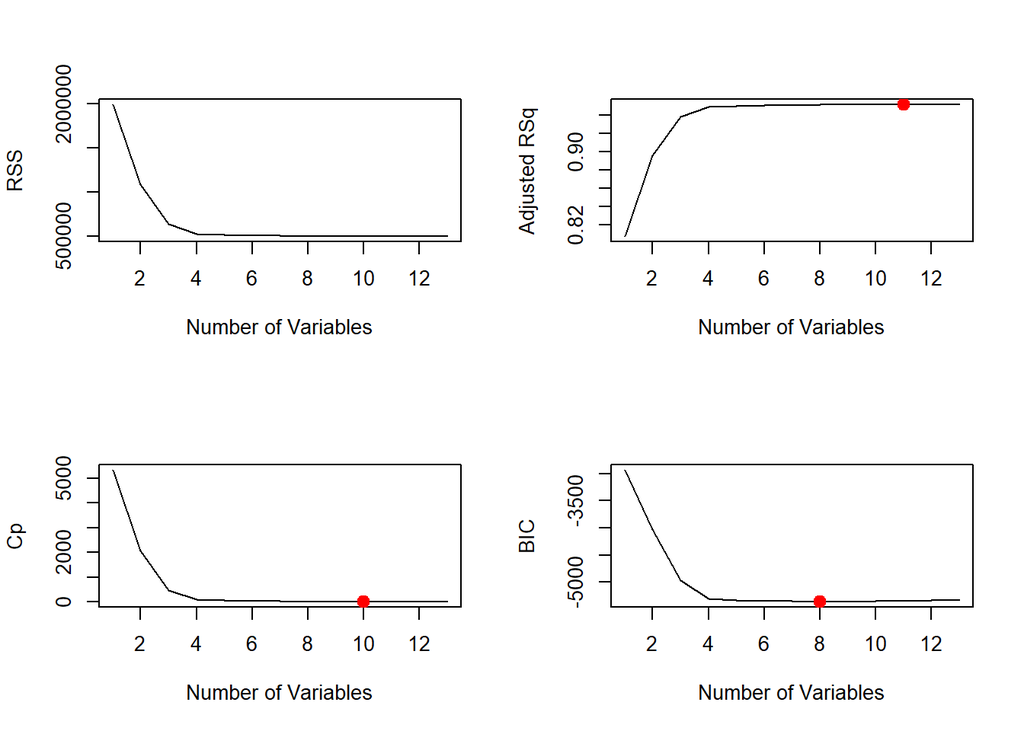

```r
par(mfrow=c(1,1))
```

- 외부기온과 외부풍속을 제외하는 것이 좋다는 결과이다.
- 외부기온과 외부풍속을 제외한 모형에 대해서 다시한번 선택해 보자.

```r
library(leaps)
ms0 <- regsubsets(내부CO2~외부CO2+외부일사량+환기창면적+작물유무+환기창면적*외부CO2+작물유무*외부CO2+작물유무*외부일사량+작물유무*환기창면적,data=plant,nvmax=8)
ms0.summary <- summary(ms0)
ms0.summary
```

```
## Subset selection object
## Call: regsubsets.formula(내부CO2 ~ 외부CO2 + 외부일사량 + 환기창면적 +
##     작물유무 + 환기창면적 * 외부CO2 + 작물유무 * 외부CO2 + 작물유무 *
##     외부일사량 + 작물유무 * 환기창면적, data = plant, nvmax = 8)
## 8 Variables  (and intercept)
##                        Forced in Forced out
## 외부CO2                    FALSE      FALSE
## 외부일사량                 FALSE      FALSE
## 환기창면적                 FALSE      FALSE
## 작물유무yes                FALSE      FALSE
## 외부CO2:환기창면적         FALSE      FALSE
## 외부CO2:작물유무yes        FALSE      FALSE
## 외부일사량:작물유무yes     FALSE      FALSE
## 환기창면적:작물유무yes     FALSE      FALSE
## 1 subsets of each size up to 8
## Selection Algorithm: exhaustive
##          외부CO2 외부일사량 환기창면적 작물유무yes 외부CO2:환기창면적
## 1  ( 1 ) " "     " "        " "        "*"         " "
## 2  ( 1 ) "*"     " "        " "        " "         "*"
## 3  ( 1 ) "*"     " "        "*"        " "         "*"
## 4  ( 1 ) "*"     " "        "*"        "*"         "*"
## 5  ( 1 ) "*"     " "        "*"        "*"         "*"
## 6  ( 1 ) "*"     " "        "*"        "*"         "*"
## 7  ( 1 ) "*"     "*"        "*"        "*"         "*"
## 8  ( 1 ) "*"     "*"        "*"        "*"         "*"
##          외부CO2:작물유무yes 외부일사량:작물유무yes 환기창면적:작물유무yes
## 1  ( 1 ) " "                 " "                    " "
## 2  ( 1 ) " "                 " "                    " "
## 3  ( 1 ) " "                 " "                    " "
## 4  ( 1 ) " "                 " "                    " "
## 5  ( 1 ) "*"                 " "                    " "
## 6  ( 1 ) "*"                 " "                    "*"
## 7  ( 1 ) "*"                 " "                    "*"
## 8  ( 1 ) "*"                 "*"                    "*"
```

```r
par(mfrow=c(2,2))
# RSS=SSE
plot(ms0.summary$rss,xlab="Number of Variables",ylab="RSS",type="l")
# Adj R^2
plot(ms0.summary$adjr2,xlab="Number of Variables",ylab="Adjusted RSq",type="l")
which.max(ms0.summary$adjr2)
```

```
## [1] 8
```

```r
points(which.max(ms0.summary$adjr2)
,ms0.summary$adjr2[which.max(ms0.summary$adjr2)
], col="red",cex=2,pch=20)
# Cp
plot(ms0.summary$cp,xlab="Number of Variables",ylab="Cp",type='l')
which.min(ms0.summary$cp)
```

```
## [1] 8
```

```r
points(which.min(ms0.summary$cp)
,ms0.summary$cp[which.min(ms0.summary$cp)
],col="red",cex=2,pch=20)
# BIC
plot(ms0.summary$bic,xlab="Number of Variables",ylab="BIC",type='l')
which.min(ms0.summary$bic)
```

```
## [1] 6
```

```r
points(which.min(ms0.summary$bic)
,ms0.summary$bic[which.min(ms0.summary$bic)
],col="red",cex=2,pch=20)
```

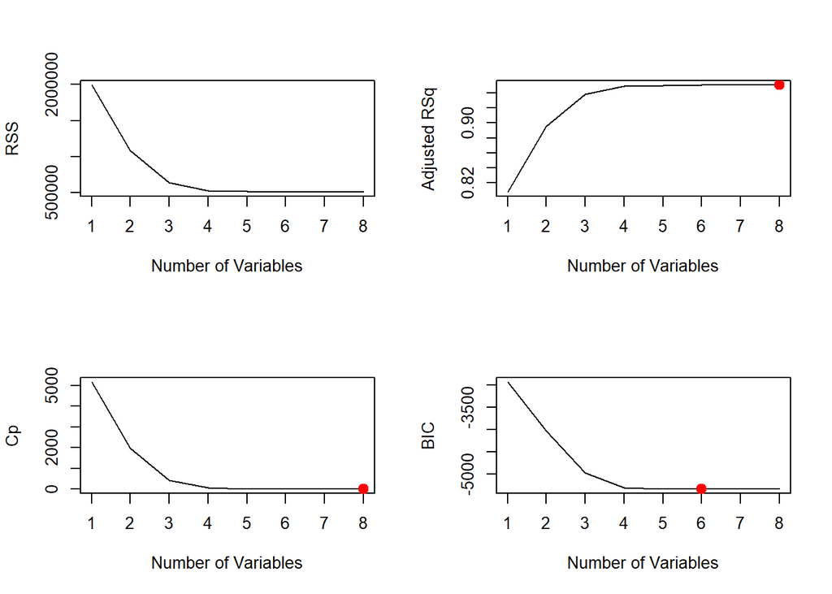

```r
par(mfrow=c(1,1))
```

- 분석결과 $R_{adj}^2$의 경우는 변수의 개수 8인 모형, $Cp$의 경우는 변수의 개수 8인 모형, 그리고 $BIC$의 경우는 변수의 개수 6인 모형을 최적으로 판단하고 있다. 이에 따라 변수의 개수 6인 모형을 최종적으로 선택하도록 한다. 복잡한 모형이라고 해서 무조건 예측력이 좋다는 보장이 없고 오히려 간단한 모형이 해석하기에는 더 좋기 때문이다.

```r
summary(lm(내부CO2~외부CO2+환기창면적+작물유무+환기창면적*외부CO2+작물유무*외부CO2+작물유무*환기창면적,data=plant))
```

```
##
## Call:
## lm(formula = 내부CO2 ~ 외부CO2 + 환기창면적 + 작물유무 + 환기창면적 *
##     외부CO2 + 작물유무 * 외부CO2 + 작물유무 * 환기창면적, data = plant)
##
## Residuals:
##     Min      1Q  Median      3Q     Max
## -59.941  -7.907  -1.816   5.519  57.529
##
## Coefficients:
##                          Estimate Std. Error t value Pr(>|t|)
## (Intercept)             -26.55510   42.32843  -0.627 0.530505
## 외부CO2                   1.27173    0.07991  15.915  < 2e-16 ***
## 환기창면적             3937.47916  322.55205  12.207  < 2e-16 ***
## 작물유무yes            -277.26481   32.84536  -8.442  < 2e-16 ***
## 외부CO2:환기창면적       -9.22296    0.60871 -15.152  < 2e-16 ***
## 외부CO2:작물유무yes       0.51777    0.07323   7.071  2.2e-12 ***
## 환기창면적:작물유무yes -246.07758   73.27339  -3.358 0.000801 ***
## ---
## Signif. codes:  0 '***' 0.001 '**' 0.01 '*' 0.05 '.' 0.1 ' ' 1
##
## Residual standard error: 16.94 on 1783 degrees of freedom
## Multiple R-squared:  0.9506, Adjusted R-squared:  0.9504
## F-statistic:  5719 on 6 and 1783 DF,  p-value: < 2.2e-16
```

#### 교차타당검증에 의한 모형 비교

```r
set.seed(5790)
train.index <- sample(1:nrow(plant), round(nrow(plant)*7/10), replace=F)
ex1_train <- plant[train.index,]
ex1_test <- plant[-train.index,]
```

```r
# 최초로 고려한 모형
m0 <- lm(내부CO2~환기율+외부기온+외부CO2+외부풍속+외부일사량+환기창면적+작물유무+환기창면적*환기율+환기창면적*외부풍속+환기창면적*외부CO2+작물유무*환기율+작물유무*외부기온+작물유무*외부CO2+작물유무*외부풍속+작물유무*외부일사량+작물유무*환기창면적,data=ex1_train)
y_hat0 <- predict(m0,ex1_test)
RMSE0 <- mean(sum((ex1_test$내부CO2-y_hat0)^2))
RMSE0
```

```
## [1] 93176.77
```

```r
# Adj R^2, Cp, BIC 등의 기준을 바탕으로 선택된 모형 (교호작용이 있는 경우는 주효과 포함)
m0 <- lm(내부CO2~외부CO2+환기창면적+작물유무+환기창면적*외부CO2+작물유무*외부CO2+작물유무*환기창면적,data=plant)
y_hat0 <- predict(m0,ex1_test)
RMSE1 <- mean(sum((ex1_test$내부CO2-y_hat0)^2))
RMSE1
```

```
## [1] 153710.7
```

```r
# 모든 주효과와 가장 중요한 교호작용 2가지를 포함한 모형
# 분석 의뢰기관의 요청에 따라 환기율은 제외 (이에 따라 환기율을 포함하는 교호작용이면 제외함)
m0 <- lm(내부CO2~외부기온+외부CO2+외부풍속+외부일사량+환기창면적+작물유무+환기창면적*외부CO2+작물유무*외부CO2,data=ex1_train)
y_hat0 <- predict(m0,ex1_test)
RMSE2 <- mean(sum((ex1_test$내부CO2-y_hat0)^2))
RMSE2
```

```
## [1] 155409.8
```

- 결과적으로 3가지 모형들 중 최초로 고려한 모형이 가장 우수하였다.

```r
summary(lm(내부CO2~환기율+외부기온+외부CO2+외부풍속+외부일사량+환기창면적+작물유무+환기창면적*환기율+환기창면적*외부풍속+환기창면적*외부CO2+작물유무*환기율+작물유무*외부기온+작물유무*외부CO2+작물유무*외부풍속+작물유무*외부일사량+작물유무*환기창면적,data=ex1_train))
```

```
##
## Call:
## lm(formula = 내부CO2 ~ 환기율 + 외부기온 + 외부CO2 + 외부풍속 +
##     외부일사량 + 환기창면적 + 작물유무 + 환기창면적 * 환기율 +
##     환기창면적 * 외부풍속 + 환기창면적 * 외부CO2 + 작물유무 *
##     환기율 + 작물유무 * 외부기온 + 작물유무 * 외부CO2 + 작물유무 *
##     외부풍속 + 작물유무 * 외부일사량 + 작물유무 * 환기창면적,
##     data = ex1_train)
##
## Residuals:
##     Min      1Q  Median      3Q     Max
## -38.964  -9.045   0.010   8.882  54.475
##
## Coefficients:
##                          Estimate Std. Error t value Pr(>|t|)
## (Intercept)            -3.170e+01  5.205e+01  -0.609  0.54254
## 환기율                  1.775e+01  3.214e+00   5.524 4.03e-08 ***
## 외부기온                2.984e-01  2.867e-01   1.041  0.29815
## 외부CO2                 1.249e+00  9.208e-02  13.563  < 2e-16 ***
## 외부풍속               -1.501e+01  1.532e+00  -9.797  < 2e-16 ***
## 외부일사량             -4.762e-03  3.918e-03  -1.215  0.22450
## 환기창면적              5.488e+03  3.634e+02  15.102  < 2e-16 ***
## 작물유무yes            -5.553e+02  4.386e+01 -12.661  < 2e-16 ***
## 환기율:환기창면적      -2.517e+02  1.092e+01 -23.047  < 2e-16 ***
## 외부풍속:환기창면적     2.069e+02  2.901e+01   7.132 1.68e-12 ***
## 외부CO2:환기창면적     -1.148e+01  6.455e-01 -17.793  < 2e-16 ***
## 환기율:작물유무yes      2.902e+01  3.428e+00   8.465  < 2e-16 ***
## 외부기온:작물유무yes    4.633e-01  3.598e-01   1.288  0.19804
## 외부CO2:작물유무yes     9.637e-01  8.706e-02  11.069  < 2e-16 ***
## 외부풍속:작물유무yes   -2.965e+01  3.523e+00  -8.417  < 2e-16 ***
## 외부일사량:작물유무yes -1.465e-02  4.823e-03  -3.039  0.00242 **
## 환기창면적:작물유무yes -3.463e+02  1.107e+02  -3.127  0.00180 **
## ---
## Signif. codes:  0 '***' 0.001 '**' 0.01 '*' 0.05 '.' 0.1 ' ' 1
##
## Residual standard error: 13.56 on 1236 degrees of freedom
## Multiple R-squared:  0.9686, Adjusted R-squared:  0.9682
## F-statistic:  2386 on 16 and 1236 DF,  p-value: < 2.2e-16
```